# final_project_reg_question

Max Ruehle

October 25, 2020

Read in the data.

```r
df = read.csv("data_cleaned.csv")
```

# Days Until Reinstatement (Regression)

One big question that we hope to be answered by this dataset is, given a prisoner eventually returns to prison, how many days will it be until they return?

Let's first look at how many prisoners actually returned to prison in this three-year span:

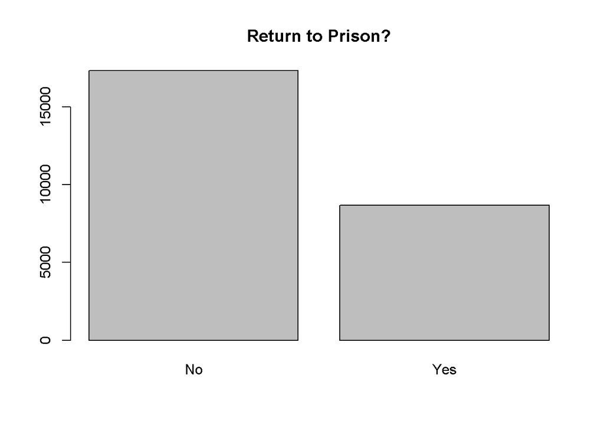

```r
barplot(table(df$Return.to.Prison), main = "Return to Prison?", names.arg = c("No", "Yes"))
```

```r
library(dplyr)
count(df, Return.to.Prison)
```

```
##   Return.to.Prison     n
## 1            FALSE 17339
## 2             TRUE  8681
```

We can see that of the 26,020 prisoners released, 8,681 ended up returning to prison within the three-year span.

Since we only want to look at those that returned, we can now subset the data:

```r
df = filter(df, Return.to.Prison == TRUE)
count(df)
```

```
##      n
## 1 8681
```

Now, we can subset the columns that are important for building our regression model and because they are all categorical data, we can turn them into factor variables for extra insurance:

```r
df = select(df, Release.Type, Race...Ethnicity, Age.At.Release, Sex, Offense.Classification, Offense.Type, Offense.Subtype, Recidivism.Type, Days.to.Return)

df$Release.Type = factor(df$Release.Type)
df$Race...Ethnicity = factor(df$Race...Ethnicity)
df$Age.At.Release = factor(df$Age.At.Release)
df$Sex = factor(df$Sex)
df$Offense.Classification = factor(df$Offense.Classification)
df$Offense.Type = factor(df$Offense.Type)
df$Offense.Subtype = factor(df$Offense.Subtype)
df$Recidivism.Type = factor(df$Recidivism.Type)
```

First, let's take a very simple model using just the Sex of the offenders. This will give us an idea of how our models will work.

```r
contrasts(df$Sex)
```

```
##        Male
## Female    0
## Male      1
```

```r
summary(lm(Days.to.Return~Sex, data = df))
```

```
##
## Call:
## lm(formula = Days.to.Return ~ Sex, data = df)
##
## Residuals:
##     Min      1Q  Median      3Q     Max
## -471.56 -232.56  -50.56  212.44  636.91
##
## Coefficients:
##             Estimate Std. Error t value Pr(>|t|)
## (Intercept)  457.094      9.031  50.614   <2e-16 ***
## SexMale       14.465      9.587   1.509    0.131
## ---
## Signif. codes:  0 '***' 0.001 '**' 0.01 '*' 0.05 '.' 0.1 ' ' 1
##
## Residual standard error: 282.3 on 8679 degrees of freedom
## Multiple R-squared:  0.0002623,  Adjusted R-squared:  0.0001471
## F-statistic: 2.277 on 1 and 8679 DF,  p-value: 0.1314
```

This isn't too difficult to understand. Our model simply says if the offender is female, the value for SexMale will be 0, giving us a Days.to.Return value of approximately 457 days. Compare this to if the offender is Male, the Days.to.Return value would be about 471 days.

Now, we obviously cannot use this model for many reasons, one of them being the p-value we get from our chosen factor is 0.131, which is quite high.

Let's build a new model using Sex, Offense Type, and Recidivism Type:

```r
contrasts(df$Sex)
```

```
##        Male
## Female    0
## Male      1
```

```r
contrasts(df$Offense.Type)
```

```
##              Other Property Public Order Violent
## Drug             0        0            0       0
## Other            1        0            0       0
## Property         0        1            0       0
## Public Order     0        0            1       0
## Violent          0        0            0       1
```

```r
contrasts(df$Recidivism.Type)
```

```
##      Tech
## New     0
## Tech    1
```

```r
summary(lm(Days.to.Return~Sex + Offense.Type + Recidivism.Type, data = df))
```

```
##
## Call:
## lm(formula = Days.to.Return ~ Sex + Offense.Type + Recidivism.Type,
##     data = df)
##
## Residuals:
##     Min      1Q  Median      3Q     Max
## -530.68 -216.90  -47.39  197.10  745.54
##
## Coefficients:
##                          Estimate Std. Error t value Pr(>|t|)
## (Intercept)               552.612     10.054  54.966  < 2e-16 ***
## SexMale                    -5.928      9.266  -0.640    0.522
## Offense.TypeOther         -14.977     12.432  -1.205    0.228
## Offense.TypeProperty      -30.390      7.324  -4.150 3.36e-05 ***
## Offense.TypePublic Order  -39.786      9.795  -4.062 4.91e-05 ***
## Offense.TypeViolent        -4.111      8.566  -0.480    0.631
## Recidivism.TypeTech      -168.832      6.095 -27.700  < 2e-16 ***
## ---
## Signif. codes:  0 '***' 0.001 '**' 0.01 '*' 0.05 '.' 0.1 ' ' 1
##
## Residual standard error: 270.5 on 8674 degrees of freedom
## Multiple R-squared:  0.08263,    Adjusted R-squared:  0.082
## F-statistic: 130.2 on 6 and 8674 DF,  p-value: < 2.2e-16
```

We can see that this model is quite an improvement over the last one. Let's split our data to get our test MSE.

```r
n = dim(df)[1]
train_index = sample(1:n,7000,rep=FALSE)
train_df = df[train_index,]
test_df = df[-train_index,]

fit = lm(Days.to.Return~Sex + Offense.Type + Recidivism.Type, data = train_df)

X_test = test_df[,-9]
predicted_values = predict(fit, X_test)
sum((test_df$Days.to.Return - predicted_values)^2)/(n/2)
```

```
## [1] 30235.38
```

```r
model0 = lm(Days.to.Return~1,data=df)
summary(model0)
```

```
##
## Call:
## lm(formula = Days.to.Return ~ 1, data = df)
##
## Residuals:
##     Min      1Q  Median      3Q     Max
## -469.93 -231.93  -51.93  212.07  625.07
##
## Coefficients:
##             Estimate Std. Error t value Pr(>|t|)
## (Intercept)   469.93       3.03   155.1   <2e-16 ***
## ---
## Signif. codes:  0 '***' 0.001 '**' 0.01 '*' 0.05 '.' 0.1 ' ' 1
##
## Residual standard error: 282.3 on 8680 degrees of freedom
```

```r
modelfull = lm(Days.to.Return~.,data=df)
summary(modelfull)
```

```
##
## Call:
## lm(formula = Days.to.Return ~ ., data = df)
##
## Residuals:
##     Min      1Q  Median      3Q     Max
## -596.04 -210.01  -48.46  189.60  781.92
##
## Coefficients: (3 not defined because of singularities)
##                                                                  Estimate
## (Intercept)                                                      618.0137
## Release.TypeDischarged - Expiration of Sentence                  -22.4076
## Release.TypeDischarged â\200“ End of Sentence                       -42.4193
## Release.TypeParole                                              -131.1964
## Release.TypeParole Granted                                      -130.9632
## Release.TypeParoled to Detainer - INS                           -117.3768
## Release.TypeParoled to Detainer - Iowa                          -181.7677
## Release.TypeParoled to Detainer - Out of State                     0.4013
## Release.TypeParoled to Detainer - U.S. Marshall                  195.4165
## Release.TypeParoled w/Immediate Discharge                        -40.7595
## Release.TypeReleased to Special Sentence                        -152.1727
## Release.TypeSpecial Sentence                                    -124.1422
## Race...EthnicityAmerican Indian or Alaska Native - Non-Hispanic  -17.5900
## Race...EthnicityAsian or Pacific Islander - Hispanic             -98.4975
## Race...EthnicityAsian or Pacific Islander - Non-Hispanic          40.6296
## Race...EthnicityBlack - Hispanic                                 -60.7366
## Race...EthnicityBlack - Non-Hispanic                              35.2115
## Race...EthnicityWhite -                                         -222.9704
## Race...EthnicityWhite - Hispanic                                  35.2874
## Race...EthnicityWhite - Non-Hispanic                              11.7620
## Age.At.Release35-44                                               12.4694
## Age.At.Release45-54                                               -4.0735
## Age.At.Release55 and Older                                       -30.0990
## Age.At.ReleaseUnder 25                                           -22.7302
## SexMale                                                          -16.7933
## Offense.ClassificationB Felony                                    66.8327
## Offense.ClassificationC Felony                                    44.2253
## Offense.ClassificationD Felony                                     9.8938
## Offense.ClassificationFelony - Enhanced                           82.6300
## Offense.ClassificationFelony - Enhancement to Original Penalty    72.7567
```

[output cut: 220 more lines]

```
## Offense.SubtypeSex Offender Registry/Residency                  0.878700
## Offense.SubtypeSpecial Sentence Revocation                            NA
## Offense.SubtypeStolen Property                                  0.030839 *
## Offense.SubtypeTheft                                            0.170377
## Offense.SubtypeTraffic                                          0.007524 **
## Offense.SubtypeTrafficking                                            NA
## Offense.SubtypeVandalism                                              NA
## Offense.SubtypeWeapons                                          0.022697 *
## Recidivism.TypeTech                                              < 2e-16 ***
## ---
## Signif. codes:  0 '***' 0.001 '**' 0.01 '*' 0.05 '.' 0.1 ' ' 1
##
## Residual standard error: 266.2 on 8620 degrees of freedom
## Multiple R-squared:  0.1171, Adjusted R-squared:  0.111
## F-statistic: 19.06 on 60 and 8620 DF,  p-value: < 2.2e-16
```

```r
step(model0,scope=list(lower=model0,upper=modelfull),direction="forward")
```

```
## Start:  AIC=97974.46
## Days.to.Return ~ 1
##
##                          Df Sum of Sq       RSS   AIC
## + Recidivism.Type         1  55071990 636682194 97256
## + Release.Type           11  30564983 661189201 97604
## + Offense.Subtype        25   6832289 684921896 97938
## + Offense.Classification  9   2983240 688770944 97955
## + Race...Ethnicity        8   2418634 689335550 97960
## + Age.At.Release          4   1292006 690462178 97966
## + Offense.Type            4    887981 690866203 97971
## + Sex                     1    181424 691572760 97974
## <none>                                691754184 97974
##
## Step:  AIC=97256.28
## Days.to.Return ~ Recidivism.Type
##
##                          Df Sum of Sq       RSS   AIC
## + Release.Type           11  10875678 625806516 97129
## + Offense.Classification  9   4620605 632061589 97211
## + Offense.Subtype        25   5862132 630820062 97226
## + Offense.Type            4   2058565 634623630 97236
## + Age.At.Release          4   1493190 635189004 97244
## + Race...Ethnicity        8   1551887 635130307 97251
## <none>                                636682194 97256
## + Sex                     1     14011 636668183 97258
##
## Step:  AIC=97128.71
## Days.to.Return ~ Recidivism.Type + Release.Type
##
##                          Df Sum of Sq       RSS   AIC
## + Offense.Classification  9   8151091 617655425 97033
## + Offense.Subtype        25   8131635 617674881 97065
## + Offense.Type            4   3676286 622130230 97086
## + Age.At.Release          4   1819704 623986812 97111
## + Race...Ethnicity        8   1480943 624325574 97124
## <none>                                625806516 97129
## + Sex                     1     64989 625741527 97130
##
## Step:  AIC=97032.9
```

[output cut: 37 more lines]

```
## + Sex           1    213912 610986969 97015
## <none>                      611200881 97016
##
## Step:  AIC=97014.14
## Days.to.Return ~ Recidivism.Type + Release.Type + Offense.Classification +
##     Age.At.Release + Offense.Subtype + Race...Ethnicity + Offense.Type
##
##        Df Sum of Sq       RSS   AIC
## + Sex   1    223300 610726556 97013
## <none>              610949857 97014
##
## Step:  AIC=97012.97
## Days.to.Return ~ Recidivism.Type + Release.Type + Offense.Classification +
##     Age.At.Release + Offense.Subtype + Race...Ethnicity + Offense.Type +
##     Sex
```

```
##
## Call:
## lm(formula = Days.to.Return ~ Recidivism.Type + Release.Type +
##     Offense.Classification + Age.At.Release + Offense.Subtype +
##     Race...Ethnicity + Offense.Type + Sex, data = df)
##
## Coefficients:
##                                                     (Intercept)
##                                                        531.2301
##                                             Recidivism.TypeTech
##                                                       -146.8492
##                 Release.TypeDischarged - Expiration of Sentence
##                                                        -22.4076
##                      Release.TypeDischarged â\200“ End of Sentence
##                                                        -42.4193
##                                              Release.TypeParole
##                                                       -131.1964
##                                      Release.TypeParole Granted
##                                                       -130.9632
##                           Release.TypeParoled to Detainer - INS
##                                                       -117.3768
##                          Release.TypeParoled to Detainer - Iowa
##                                                       -181.7677
##                  Release.TypeParoled to Detainer - Out of State
##                                                          0.4013
##                 Release.TypeParoled to Detainer - U.S. Marshall
##                                                        195.4165
##                       Release.TypeParoled w/Immediate Discharge
##                                                        -40.7595
##                        Release.TypeReleased to Special Sentence
##                                                       -152.1727
##                                    Release.TypeSpecial Sentence
##                                                       -124.1422
##                                  Offense.ClassificationB Felony
##                                                         66.8327
##                                  Offense.ClassificationC Felony
##                                                         44.2253
##                                  Offense.ClassificationD Felony
##                                                          9.8938
##                         Offense.ClassificationFelony - Enhanced
```

[output cut: 80 more lines]

```
##                                                       -222.9704
##                                Race...EthnicityWhite - Hispanic
##                                                         35.2874
##                            Race...EthnicityWhite - Non-Hispanic
##                                                         11.7620
##                                               Offense.TypeOther
##                                                        127.6062
##                                            Offense.TypeProperty
##                                                              NA
##                                        Offense.TypePublic Order
##                                                              NA
##                                             Offense.TypeViolent
##                                                              NA
##                                                         SexMale
##                                                        -16.7933
```

```r
step(modelfull,scope=list(lower=model0,upper=modelfull),direction="backward")
```

```
## Start:  AIC=97012.97
## Days.to.Return ~ Release.Type + Race...Ethnicity + Age.At.Release +
##     Sex + Offense.Classification + Offense.Type + Offense.Subtype +
##     Recidivism.Type
##
##                          Df Sum of Sq       RSS   AIC
## <none>                                610726556 97013
## - Sex                     1    223300 610949857 97014
## - Offense.Type            1    260413 610986969 97015
## - Race...Ethnicity        8   1328434 612054990 97016
## - Offense.Subtype        22   3387088 614113644 97017
## - Age.At.Release          4   1279970 612006526 97023
## - Offense.Classification  9   3546942 614273498 97045
## - Release.Type           11  14936115 625662671 97201
## - Recidivism.Type         1  36254276 646980832 97512
```

```
##
## Call:
## lm(formula = Days.to.Return ~ Release.Type + Race...Ethnicity +
##     Age.At.Release + Sex + Offense.Classification + Offense.Type +
##     Offense.Subtype + Recidivism.Type, data = df)
##
## Coefficients:
##                                                     (Intercept)
##                                                        618.0137
##                 Release.TypeDischarged - Expiration of Sentence
##                                                        -22.4076
##                      Release.TypeDischarged â\200“ End of Sentence
##                                                        -42.4193
##                                              Release.TypeParole
##                                                       -131.1964
##                                      Release.TypeParole Granted
##                                                       -130.9632
##                           Release.TypeParoled to Detainer - INS
##                                                       -117.3768
##                          Release.TypeParoled to Detainer - Iowa
##                                                       -181.7677
##                  Release.TypeParoled to Detainer - Out of State
##                                                          0.4013
##                 Release.TypeParoled to Detainer - U.S. Marshall
##                                                        195.4165
##                       Release.TypeParoled w/Immediate Discharge
##                                                        -40.7595
##                        Release.TypeReleased to Special Sentence
##                                                       -152.1727
##                                    Release.TypeSpecial Sentence
##                                                       -124.1422
## Race...EthnicityAmerican Indian or Alaska Native - Non-Hispanic
##                                                        -17.5900
##            Race...EthnicityAsian or Pacific Islander - Hispanic
##                                                        -98.4975
##        Race...EthnicityAsian or Pacific Islander - Non-Hispanic
##                                                         40.6296
##                                Race...EthnicityBlack - Hispanic
##                                                        -60.7366
##                            Race...EthnicityBlack - Non-Hispanic
```

[output cut: 80 more lines]

```
##                                                              NA
##                                  Offense.SubtypeStolen Property
##                                                       -293.4326
##                                            Offense.SubtypeTheft
##                                                        -38.5557
##                                          Offense.SubtypeTraffic
##                                                         84.3158
##                                      Offense.SubtypeTrafficking
##                                                              NA
##                                        Offense.SubtypeVandalism
##                                                              NA
##                                          Offense.SubtypeWeapons
##                                                         80.2587
##                                             Recidivism.TypeTech
##                                                       -146.8492
```

```r
step(modelfull,scope=list(lower=model0,upper=modelfull),direction="both")
```

```
## Start:  AIC=97012.97
## Days.to.Return ~ Release.Type + Race...Ethnicity + Age.At.Release +
##     Sex + Offense.Classification + Offense.Type + Offense.Subtype +
##     Recidivism.Type
##
##                          Df Sum of Sq       RSS   AIC
## <none>                                610726556 97013
## - Sex                     1    223300 610949857 97014
## - Offense.Type            1    260413 610986969 97015
## - Race...Ethnicity        8   1328434 612054990 97016
## - Offense.Subtype        22   3387088 614113644 97017
## - Age.At.Release          4   1279970 612006526 97023
## - Offense.Classification  9   3546942 614273498 97045
## - Release.Type           11  14936115 625662671 97201
## - Recidivism.Type         1  36254276 646980832 97512
```

```
##
## Call:
## lm(formula = Days.to.Return ~ Release.Type + Race...Ethnicity +
##     Age.At.Release + Sex + Offense.Classification + Offense.Type +
##     Offense.Subtype + Recidivism.Type, data = df)
##
## Coefficients:
##                                                     (Intercept)
##                                                        618.0137
##                 Release.TypeDischarged - Expiration of Sentence
##                                                        -22.4076
##                      Release.TypeDischarged â\200“ End of Sentence
##                                                        -42.4193
##                                              Release.TypeParole
##                                                       -131.1964
##                                      Release.TypeParole Granted
##                                                       -130.9632
##                           Release.TypeParoled to Detainer - INS
##                                                       -117.3768
##                          Release.TypeParoled to Detainer - Iowa
##                                                       -181.7677
##                  Release.TypeParoled to Detainer - Out of State
##                                                          0.4013
##                 Release.TypeParoled to Detainer - U.S. Marshall
##                                                        195.4165
##                       Release.TypeParoled w/Immediate Discharge
##                                                        -40.7595
##                        Release.TypeReleased to Special Sentence
##                                                       -152.1727
##                                    Release.TypeSpecial Sentence
##                                                       -124.1422
## Race...EthnicityAmerican Indian or Alaska Native - Non-Hispanic
##                                                        -17.5900
##            Race...EthnicityAsian or Pacific Islander - Hispanic
##                                                        -98.4975
##        Race...EthnicityAsian or Pacific Islander - Non-Hispanic
##                                                         40.6296
##                                Race...EthnicityBlack - Hispanic
##                                                        -60.7366
##                            Race...EthnicityBlack - Non-Hispanic
```

[output cut: 80 more lines]

```
##                                                              NA
##                                  Offense.SubtypeStolen Property
##                                                       -293.4326
##                                            Offense.SubtypeTheft
##                                                        -38.5557
##                                          Offense.SubtypeTraffic
##                                                         84.3158
##                                      Offense.SubtypeTrafficking
##                                                              NA
##                                        Offense.SubtypeVandalism
##                                                              NA
##                                          Offense.SubtypeWeapons
##                                                         80.2587
##                                             Recidivism.TypeTech
##                                                       -146.8492
```

```r
predicted_values = predict(modelfull, X_test)
sum((test_df$Days.to.Return - predicted_values)^2)/(n/2)
```

```
## [1] 28898.74
```

It is obvious that much more data is necessary to accurately produce the time it takes to predict when an inmate will commit another crime. This is a great example of how, with more data, we could come closer to predicting when when someone will commit another crime, but we also have to keep in mind that data cannot tell us the full story. It is extremely hard to predict what a person will do because there is often different motives for why someone needs to do something (e.g. commiting a crime).